# tutorial3_answer

XuanlongQIN

2024-03-04

# Problem set 3- take Amherst as Examples

## 1. Makeing sure you have installed R Markdown

```r
library(igraph)
```

## 2.Clear your Environment

```r
rm(list = ls())
```

## 3. Clustering in Network (Take Random Walk as examples)

### 3.1 Summarzie your data

```r
data_colorado <- read.csv("/Users/xuanlong/Documents/cuhk/courses/3102/tutorial3_materials/dataset/Amherst_College.csv", header = TRUE)
```

### 3.2 Calcute Network Density

```r
set.seed(123) # we need to fix a random seed number to make your code is reproducible

## Create an directed graph from the edge list
graph_col <- graph.data.frame(data_colorado, directed = TRUE)

### Delete self-loops and multiple Edges
g_simplified <- simplify(graph_col,remove.multiple = TRUE, remove.loops = TRUE)
is_simple(g_simplified)
```

```
## [1] TRUE
```

```r
### Calculation
network_density <- graph.density(g_simplified)
network_density_2 <- edge_density(g_simplified)
network_density_2
```

```
## [1] 0.2810458
```

**Notes. Q1** Please Check whether he/she use the simplified graph as the input of graph.density().

If he/she did, then the result won’t higher than 1 or lower than 0. Otherwise, His/her result is wrong.

### 3.3 Conducting Clustering Algorithms (Take random walk as an example)

```r
# Perform the walktrap community detection algorithm
walktrap_community <- cluster_walktrap(graph_col)

# To see the membership (cluster assignment) of each vertex
mem_uni <- membership(walktrap_community)

# To see the sizes of the communities
community_size <- sizes(walktrap_community)
```

#### 3.4 Define the colors for different communities

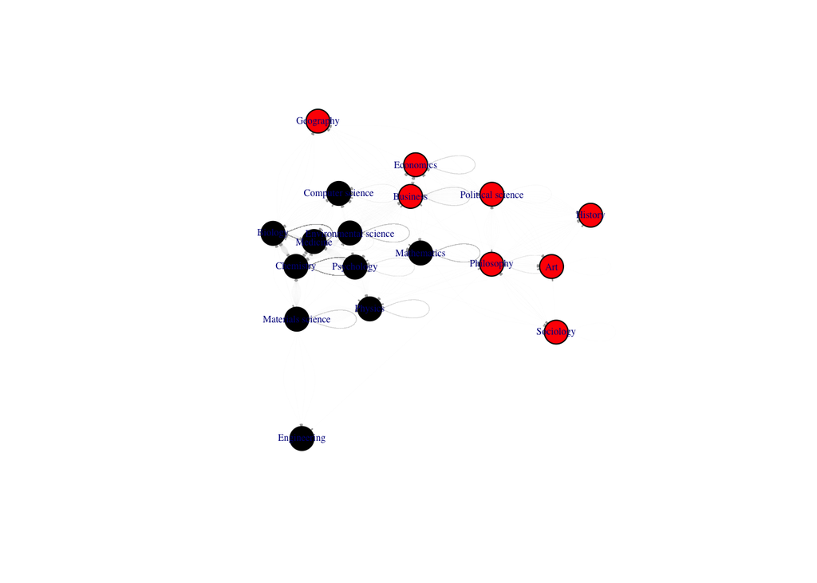

```r
# Define the colors for the four communities
community_colors <- c("black", "red", "blue", "gray")

# Map the membership vector to the corresponding colors
node_colors <- community_colors[membership(walktrap_community)]


# Plot the graph with nodes colored by their cluster membership
plot(graph_col,vertex.color = node_colors,
     vertex.label.cex = 0.5,
     edge.width = 0.01,
     edge.arrow.size=0.1,
     edge.arrow.width=0.05)
```

**Notes: Q3**

No matter whether he/she plots this graph, it won’t affect their score, just make sure they change the color of nodes instead of Community in his/her code. Because I don’t teach them how to change the color of community.

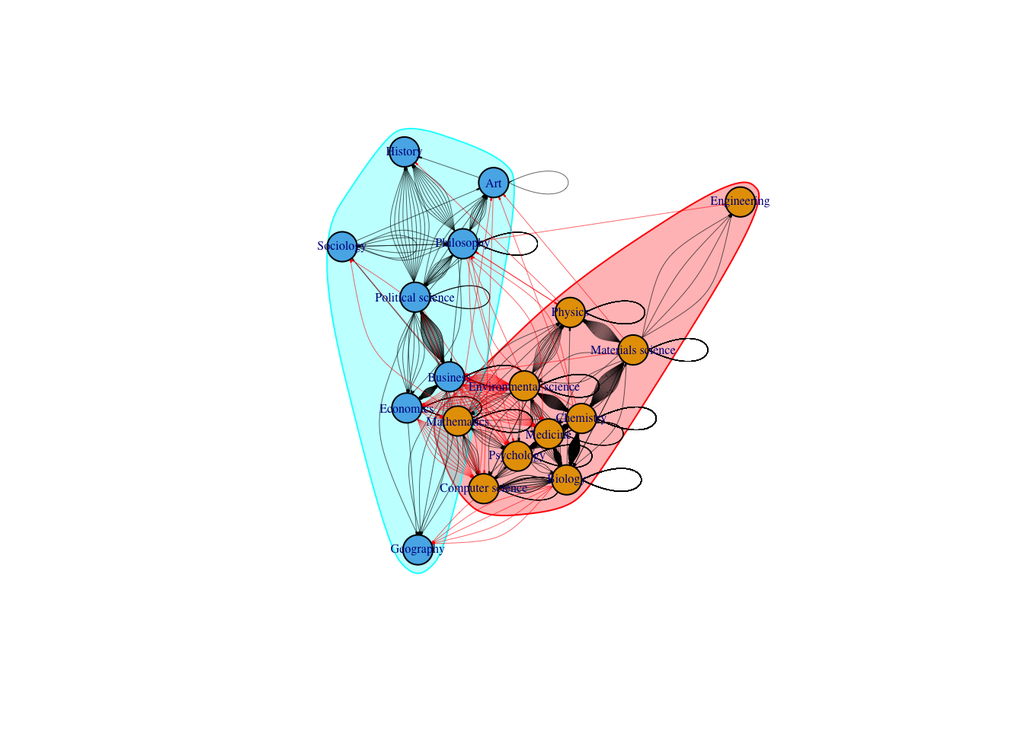

```r
plot(walktrap_community, graph_col, vertex.color = community_colors,
     vertex.label.cex = 0.5,
     edge.width = 0.3,
     edge.arrow.size = 0.1,
     edge.arrow.width = 0.05)
```

**Notes Q2** Please make sure he/she use the original graph as input rather than simplified graph. It is quite easy to check it. if this graph has multiple ties between nodes, then he/she uses original graph. If there is only one tie between two nodes, which means he/she in a wrong way!

You can add or minus his/her scores if his/her picture looks beautiful or ugly.